# Assignment 10B – Nobel Prize JSON Codebase

# Building Tidy Data Frames

Four tidy tables are built from the nested JSON. Each answers a different level of question.

## Prize-level table

One row per prize award, used for the category and decade summaries.

```r
prizes_tbl <- map_dfr(prizes_raw, function(prize) {
  tibble(
    award_year = as.integer(prize$awardYear %||% NA_character_),
    category = get_en_value(prize$category),
    category_full = get_en_value(prize$categoryFullName)
  )
}) %>%
  distinct() %>%
  mutate(decade = floor(award_year / 10) * 10)

glimpse(prizes_tbl)
```

```
## Rows: 688
## Columns: 4
## $ award_year    <int> 1901, 1901, 1901, 1901, 1901, 1902, 1902, 1902, 1902, 19…
## $ category      <chr> "Chemistry", "Literature", "Peace", "Physics", "Physiolo…
## $ category_full <chr> "The Nobel Prize in Chemistry", "The Nobel Prize in Lite…
## $ decade        <dbl> 1900, 1900, 1900, 1900, 1900, 1900, 1900, 1900, 1900, 19…
```

## Laureate-level table

One row per laureate with core birth information. Both the birth country as recorded at the time and the present-day country name (`countryNow`) are kept. Present-day names make countries comparable across political changes, for example places that were in the German Empire or Austria-Hungary at the time.

```r
laureates_tbl <- map_dfr(laureates_raw, function(laureate) {
  tibble(
    laureate_id = as.character(laureate$id %||% NA_character_),
    laureate_name = coalesce(
      get_en_value(laureate$knownName),
      get_en_value(laureate$fullName),
      get_en_value(laureate$orgName)
    ),
    gender = as.character(laureate$gender %||% NA_character_),
    birth_country = get_en_value(laureate$birth$place$country),
    birth_country_now = get_en_value(laureate$birth$place$countryNow)
  )
})

glimpse(laureates_tbl)
```

```
## Rows: 1,028
## Columns: 5
## $ laureate_id       <chr> "745", "102", "779", "259", "1004", "114", "982", "9…
## $ laureate_name     <chr> "A. Michael Spence", "Aage N. Bohr", "Aaron Ciechano…
## $ gender            <chr> "male", "male", "male", "male", "male", "male", "mal…
## $ birth_country     <chr> "USA", "Denmark", "British Protectorate of Palestine…
## $ birth_country_now <chr> "USA", "Denmark", "Israel", "Lithuania", NA, "Pakist…
```

## Laureate–prize table

The `nobelPrizes` field inside each laureate is a list, because some people won more than once. This table expands it so each laureate–prize combination is one row.

```r
laureate_prizes_tbl <- map_dfr(laureates_raw, function(laureate) {
  prizes <- laureate$nobelPrizes
  if (is.null(prizes) || length(prizes) == 0) return(tibble())

  laureate_id <- as.character(laureate$id %||% NA_character_)
  laureate_name <- coalesce(
    get_en_value(laureate$knownName),
    get_en_value(laureate$fullName),
    get_en_value(laureate$orgName)
  )
  birth_country <- get_en_value(laureate$birth$place$country)
  birth_country_now <- get_en_value(laureate$birth$place$countryNow)

  map_dfr(prizes, function(prize) {
    tibble(
      laureate_id = laureate_id,
      laureate_name = laureate_name,
      birth_country = birth_country,
      birth_country_now = birth_country_now,
      award_year = as.integer(prize$awardYear %||% NA_character_),
      category = get_en_value(prize$category),
      motivation = get_en_value(prize$motivation)
    )
  })
}) %>%
  mutate(decade = floor(award_year / 10) * 10)

glimpse(laureate_prizes_tbl)
```

```
## Rows: 1,036
## Columns: 8
## $ laureate_id       <chr> "745", "102", "779", "259", "1004", "114", "982", "9…
## $ laureate_name     <chr> "A. Michael Spence", "Aage N. Bohr", "Aaron Ciechano…
## $ birth_country     <chr> "USA", "Denmark", "British Protectorate of Palestine…
## $ birth_country_now <chr> "USA", "Denmark", "Israel", "Lithuania", NA, "Pakist…
## $ award_year        <int> 2001, 1975, 2004, 1982, 2021, 1979, 2019, 2019, 2009…
## $ category          <chr> "Economic Sciences", "Physics", "Chemistry", "Chemis…
## $ motivation        <chr> "for their analyses of markets with asymmetric infor…
## $ decade            <dbl> 2000, 1970, 2000, 1980, 2020, 1970, 2010, 2010, 2000…
```

## Laureate–prize–affiliation table

Each prize record can list one or more affiliations (the institutions the laureate was associated with when awarded). This table pulls the affiliation country, preferring the present-day name, and is used for Question 4. Prizes with no affiliation (for example Peace or Literature awards to individuals, or organizations) keep a row with a missing affiliation country.

```r
affiliations_tbl <- map_dfr(laureates_raw, function(laureate) {
  prizes <- laureate$nobelPrizes
  if (is.null(prizes) || length(prizes) == 0) return(tibble())

  laureate_id <- as.character(laureate$id %||% NA_character_)
  laureate_name <- coalesce(
    get_en_value(laureate$knownName),
    get_en_value(laureate$fullName),
    get_en_value(laureate$orgName)
  )
  birth_country <- get_en_value(laureate$birth$place$country)
  birth_country_now <- get_en_value(laureate$birth$place$countryNow)

  map_dfr(prizes, function(prize) {
    affiliations <- prize$affiliations
    award_year <- as.integer(prize$awardYear %||% NA_character_)
    category <- get_en_value(prize$category)

    # One row per affiliation; one NA row if none are listed
    aff_countries <- if (is.null(affiliations) || length(affiliations) == 0) {
      NA_character_
    } else {
      map_chr(affiliations, function(aff) {
        coalesce(get_en_value(aff$countryNow), get_en_value(aff$country))
      })
    }

    tibble(
      laureate_id = laureate_id,
      laureate_name = laureate_name,
      birth_country = birth_country,
      birth_country_now = birth_country_now,
      award_year = award_year,
      category = category,
      affiliation_country = aff_countries
    )
  })
}) %>%
  mutate(decade = floor(award_year / 10) * 10)

glimpse(affiliations_tbl)
```

```
## Rows: 1,126
## Columns: 8
## $ laureate_id         <chr> "745", "102", "779", "259", "1004", "114", "114", …
## $ laureate_name       <chr> "A. Michael Spence", "Aage N. Bohr", "Aaron Ciecha…
## $ birth_country       <chr> "USA", "Denmark", "British Protectorate of Palesti…
## $ birth_country_now   <chr> "USA", "Denmark", "Israel", "Lithuania", NA, "Paki…
## $ award_year          <int> 2001, 1975, 2004, 1982, 2021, 1979, 1979, 2019, 20…
## $ category            <chr> "Economic Sciences", "Physics", "Chemistry", "Chem…
## $ affiliation_country <chr> "USA", "Denmark", "Israel", "United Kingdom", NA, …
## $ decade              <dbl> 2000, 1970, 2000, 1980, 2020, 1970, 1970, 2010, 20…
```

# Validation Checks

These checks confirm that the data were retrieved in full, that key fields were created, and that the unnesting behaved as expected.

```r
tibble(
  table = c("prizes_tbl", "laureates_tbl", "laureate_prizes_tbl", "affiliations_tbl"),
  rows = c(nrow(prizes_tbl), nrow(laureates_tbl),
           nrow(laureate_prizes_tbl), nrow(affiliations_tbl))
) %>%
  kable(caption = "Row counts for the tidy tables")
```

Row counts for the tidy tables

| table | rows |
| --- | --- |
| prizes_tbl | 688 |
| laureates_tbl | 1028 |
| laureate_prizes_tbl | 1036 |
| affiliations_tbl | 1126 |

```r
tibble(
  min_award_year = min(prizes_tbl$award_year, na.rm = TRUE),
  max_award_year = max(prizes_tbl$award_year, na.rm = TRUE),
  distinct_categories = n_distinct(prizes_tbl$category),
  missing_birth_country = sum(is.na(laureates_tbl$birth_country_now)),
  missing_affiliation_country = sum(is.na(affiliations_tbl$affiliation_country))
) %>%
  kable(caption = "Basic validation checks")
```

Basic validation checks

| min_award_year | max_award_year | distinct_categories | missing_birth_country | missing_affiliation_country |
| --- | --- | --- | --- | --- |
| 1901 | 2026 | 6 | 31 | 273 |

```r
# Every laureate-prize row should come from a laureate in laureates_tbl,
# and the affiliation table can only be as large or larger than the
# laureate-prize table (one or more rows per prize).
stopifnot(
  all(laureate_prizes_tbl$laureate_id %in% laureates_tbl$laureate_id),
  nrow(affiliations_tbl) >= nrow(laureate_prizes_tbl)
)
```

The missing birth and affiliation counts are expected. Organizations (such as the Red Cross) have no birth place, and many Peace and Literature prizes have no listed affiliation.

# Question 1: Which Categories Have Been Awarded Most Frequently?

```r
q1_category_counts <- prizes_tbl %>%
  count(category, sort = TRUE)

kable(q1_category_counts, caption = "Nobel Prize categories ranked by number of awards")
```

Nobel Prize categories ranked by number of awards

| category | n |
| --- | --- |
| Chemistry | 126 |
| Literature | 126 |
| Peace | 126 |
| Physics | 126 |
| Physiology or Medicine | 126 |
| Economic Sciences | 58 |

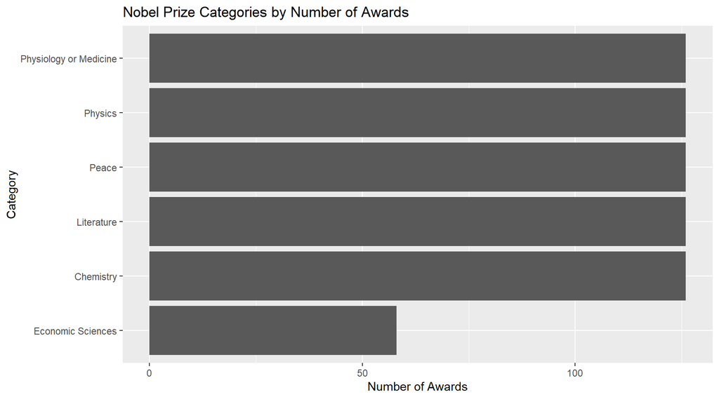

```r
ggplot(q1_category_counts, aes(x = reorder(category, n), y = n)) +
  geom_col() +
  coord_flip() +
  labs(
    title = "Nobel Prize Categories by Number of Awards",
    x = "Category",
    y = "Number of Awards"
  )
```

**Interpretation.** Chemistry has the highest count in this pull of the data, with 126 awards. The five original categories (Chemistry, Literature, Peace, Physics, and Physiology or Medicine) have the same or nearly the same totals because they have been awarded since 1901. Economic Sciences has the lowest count (58 awards for Economic Sciences) because it was introduced much later, in 1969.

# Question 2: Which Decades Have Had the Most Nobel Prize Awards?

```r
q2_decade_counts <- prizes_tbl %>%
  filter(!is.na(decade)) %>%
  count(decade, sort = TRUE)

kable(q2_decade_counts, caption = "Number of Nobel Prize awards by decade")
```

Number of Nobel Prize awards by decade

| decade | n |
| --- | --- |
| 1970 | 60 |
| 1980 | 60 |
| 1990 | 60 |
| 2000 | 60 |
| 2010 | 60 |
| 1960 | 51 |
| 1910 | 50 |
| 1920 | 50 |
| 1930 | 50 |
| 1940 | 50 |
| 1950 | 50 |
| 1900 | 45 |
| 2020 | 42 |

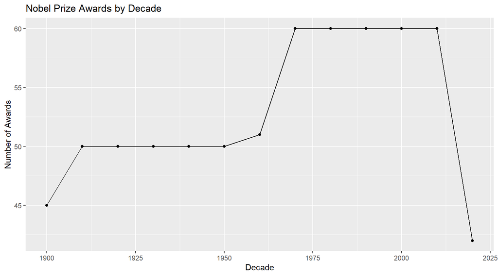

```r
ggplot(q2_decade_counts, aes(x = decade, y = n)) +
  geom_line() +
  geom_point() +
  labs(
    title = "Nobel Prize Awards by Decade",
    x = "Decade",
    y = "Number of Awards"
  )
```

# Question 3: Which Birth Countries Have Produced the Most Laureates?

```r
q3_birth_country_counts <- laureates_tbl %>%
  filter(!is.na(birth_country_now)) %>%
  count(birth_country_now, sort = TRUE)

q3_birth_country_counts %>%
  slice_head(n = 15) %>%
  kable(caption = "Top 15 present-day birth countries of Nobel laureates")
```

Top 15 present-day birth countries of Nobel laureates

| birth_country_now | n |
| --- | --- |
| USA | 299 |
| United Kingdom | 94 |
| Germany | 86 |
| France | 64 |
| Japan | 31 |
| Sweden | 30 |
| Russia | 29 |
| Poland | 28 |
| Canada | 23 |
| Italy | 20 |
| the Netherlands | 20 |
| Austria | 19 |
| Switzerland | 19 |
| Norway | 13 |
| China | 12 |

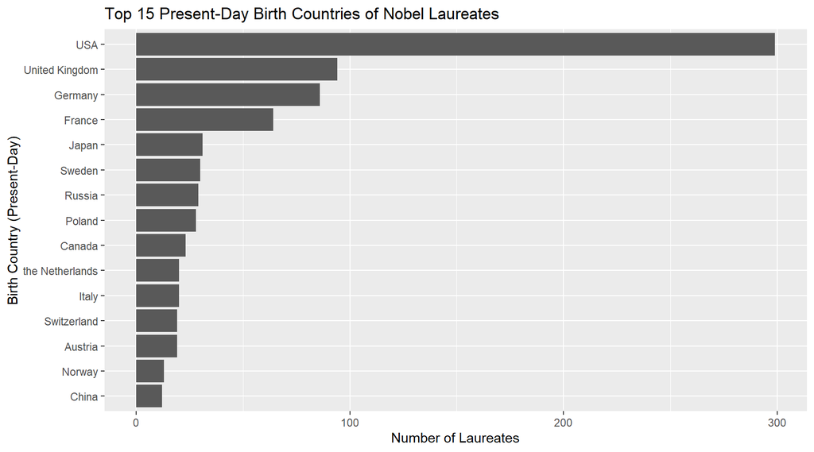

```r
q3_birth_country_counts %>%
  slice_head(n = 15) %>%
  ggplot(aes(x = reorder(birth_country_now, n), y = n)) +
  geom_col() +
  coord_flip() +
  labs(
    title = "Top 15 Present-Day Birth Countries of Nobel Laureates",
    x = "Birth Country (Present-Day)",
    y = "Number of Laureates"
  )
```

**Interpretation.** USA is first with 299 laureates, followed by United Kingdom (94) and Germany (86). Nobel laureates are heavily concentrated in a small number of countries. Counts are by individual laureate and use present-day country names, and laureates with no recorded birth place (mostly organizations) are excluded.

# Question 4: Which Countries Appear to Lose the Most Laureates?

This question compares each laureate’s **present-day birth country** with the **country of their award-time affiliation**. When the two differ, the laureate is treated as having moved across countries. A laureate–prize is counted once per birth country and affiliation country combination, and only rows where both countries are known are used.

```r
cross_country_rows <- affiliations_tbl %>%
  filter(
    !is.na(birth_country_now),
    !is.na(affiliation_country),
    birth_country_now != affiliation_country
  ) %>%
  distinct(laureate_id, award_year, category, birth_country_now, affiliation_country)

q4_country_loss <- cross_country_rows %>%
  count(birth_country_now, sort = TRUE)

q4_country_loss %>%
  slice_head(n = 15) %>%
  kable(caption = "Top 15 birth countries whose laureates were affiliated with another country at the time of the award")
```

Top 15 birth countries whose laureates were affiliated with another country at the time of the award

| birth_country_now | n |
| --- | --- |
| Germany | 27 |
| United Kingdom | 25 |
| Poland | 20 |
| Canada | 15 |
| France | 15 |
| Austria | 12 |
| Russia | 12 |
| the Netherlands | 10 |
| Hungary | 9 |
| Scotland | 9 |
| Italy | 8 |
| Japan | 8 |
| China | 7 |
| Australia | 6 |
| India | 5 |

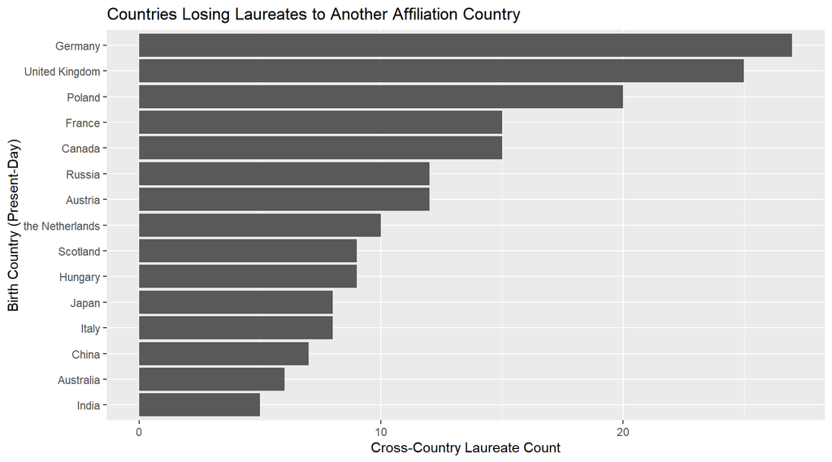

```r
q4_country_loss %>%
  slice_head(n = 15) %>%
  ggplot(aes(x = reorder(birth_country_now, n), y = n)) +
  geom_col() +
  coord_flip() +
  labs(
    title = "Countries Losing Laureates to Another Affiliation Country",
    x = "Birth Country (Present-Day)",
    y = "Cross-Country Laureate Count"
  )
```

## Country-to-country flows

```r
q4_flows <- cross_country_rows %>%
  count(birth_country_now, affiliation_country, sort = TRUE)

q4_flows %>%
  slice_head(n = 15) %>%
  kable(caption = "Most common cross-country laureate flows (birth country to affiliation country)")
```

Most common cross-country laureate flows (birth country to affiliation country)

| birth_country_now | affiliation_country | n |
| --- | --- | --- |
| United Kingdom | USA | 19 |
| Canada | USA | 15 |
| Germany | USA | 14 |
| France | USA | 9 |
| Poland | Germany | 9 |
| Japan | USA | 8 |
| Scotland | United Kingdom | 7 |
| China | USA | 6 |
| Poland | USA | 6 |
| Russia | USA | 6 |
| Austria | Germany | 5 |
| Austria | USA | 5 |
| Hungary | USA | 5 |
| Italy | USA | 5 |
| Germany | Switzerland | 4 |

## Destination countries

Total cross-country laureates received by each affiliation country.

```r
q4_destinations <- q4_flows %>%
  group_by(affiliation_country) %>%
  summarise(n = sum(n), .groups = "drop") %>%
  arrange(desc(n))

q4_destinations %>%
  slice_head(n = 10) %>%
  kable(caption = "Top 10 destination (affiliation) countries for cross-country laureates")
```

Top 10 destination (affiliation) countries for cross-country laureates

| affiliation_country | n |
| --- | --- |
| USA | 143 |
| United Kingdom | 38 |
| Germany | 26 |
| Switzerland | 13 |
| France | 11 |
| Canada | 6 |
| Sweden | 4 |
| Denmark | 3 |
| Israel | 3 |
| Russia | 3 |

## Share of each country’s laureate awards that crossed borders

Raw counts favor countries with many laureates. This table puts the counts in proportion by dividing each country’s cross-country awards by all of its laureate awards that have a known affiliation country.

```r
known_affiliation_awards <- affiliations_tbl %>%
  filter(!is.na(birth_country_now), !is.na(affiliation_country)) %>%
  distinct(laureate_id, award_year, category, birth_country_now) %>%
  count(birth_country_now, name = "awards_with_affiliation")

cross_awards <- cross_country_rows %>%
  distinct(laureate_id, award_year, category, birth_country_now) %>%
  count(birth_country_now, name = "cross_country_awards")

q4_share <- cross_awards %>%
  left_join(known_affiliation_awards, by = "birth_country_now") %>%
  mutate(pct_cross_country = round(100 * cross_country_awards / awards_with_affiliation, 1)) %>%
  filter(awards_with_affiliation >= 10) %>%
  arrange(desc(pct_cross_country))

q4_share %>%
  slice_head(n = 15) %>%
  kable(caption = "Countries (10 or more awards with a known affiliation) ranked by share of awards with a cross-country affiliation")
```

Countries (10 or more awards with a known affiliation) ranked by share of awards with a cross-country affiliation

| birth_country_now | cross_country_awards | awards_with_affiliation | pct_cross_country |
| --- | --- | --- | --- |
| Poland | 19 | 19 | 100.0 |
| Hungary | 9 | 10 | 90.0 |
| Canada | 15 | 19 | 78.9 |
| Austria | 11 | 15 | 73.3 |
| Italy | 8 | 13 | 61.5 |
| Russia | 11 | 20 | 55.0 |
| the Netherlands | 9 | 18 | 50.0 |
| Germany | 27 | 74 | 36.5 |
| France | 15 | 43 | 34.9 |
| Switzerland | 5 | 15 | 33.3 |
| Japan | 8 | 27 | 29.6 |
| United Kingdom | 24 | 84 | 28.6 |
| Sweden | 3 | 17 | 17.6 |
| USA | 5 | 274 | 1.8 |

**Interpretation.** By raw count, Germany, United Kingdom, and Poland appear most often, meaning many laureates born there were affiliated with institutions in another country at the time of the award. The destination table shows that USA receives the most cross-country laureates (143), which suggests it has been a major attractor of Nobel-level researchers. The share table is a useful check because raw counts are driven partly by how many laureates a country has. Two cautions apply: affiliation is recorded only for some prizes, so the results describe laureates with known affiliations rather than all laureates, and “loses” describes where laureates were working at the time of the award, not why they moved.

# Conclusion

The Nobel Prize API data were retrieved in full, converted from nested JSON into tidy tables, validated, and used to answer four questions. The analysis showed how awards are distributed across categories, how activity changed across decades, which countries produced the most laureates, and which countries’ laureates most often worked abroad at the time of the award. Together these steps cover JSON retrieval, nested-data handling, tidy transformation, and comparative analysis in one reproducible R Markdown workflow.

# References

NobelPrize.org. *Nobel Prize API (version 2.1) and Developer Zone*. https://www.nobelprize.org/about/developer-zone-2/